# Species distribution model with GAM

Guillaume Blanchet & Steve Vissault

November 19th, 2019

# Introduction

In the present document, we will focus on the distribution of *Acanthis flammea*.

# Load R packages

```r
library(raster)
```

# Load the data

Download the data at:

1. Birds data
2. Climate
3. Roads

# Extract and organize the data

Let’s organize the data based on what we learned from logistic regression.

```r
# Species data
sp <- bird$Acanthis.flammea
spDat <- values(sp)

# Climate data
climateAll <- values(climatePresent)
climateDat <- scale(climateAll)
climateDat <- as.data.frame(climateDat)

# Pixels within 50 km of roads
roadDat <- values(road)
road50 <- which(roadDat < 50000)

# Build the raster for the subset region
roadSub <- raster(road)
values(roadSub)[road50] <- values(road)[road50]

# Make sure only land pixels are considered
roadSub <- mask(roadSub, climatePresent[[1]])

# Find pixels with values
locPixRoad <- which(!is.na(values(roadSub)))

# For the species
spSub <- spDat[locPixRoad]

# For the climate
climateSub <- climateDat[locPixRoad,]
colnames(climateSub) <- colnames(climateDat)
climateSub <- as.data.frame(climateSub)
```

# Build the model

To perform generalized additive model you need to load the R package `mgcv`.

```r
library(mgcv)
```

Generalized additive models can be very useful to account for the non-linearity of space in the response variable.

```r
# Extract coordinates
xyAll <- coordinates(sp)
xySub <- xyAll[locPixRoad,]

explanaAll <- as.data.frame(cbind(climateDat, xyAll))
explanaSub <- explanaAll[locPixRoad,]

# Build formula
formu <- as.formula(paste0("spSub ~ ",
                           paste0("bio",1:19, collapse = "+"),
                           "+ s(x,y, bs = 'tp')"))

# Model estimation
spGAM <- gam(formu,
             data = explanaSub,
             family = binomial(link = "logit"))
```

Let’s now study the regression parameters to understand the environmental component that structure *Acanthis flammea*. Do they differ from the logistic regression? How?

```r
summary(spGAM)
```

```
##
## Family: binomial
## Link function: logit
##
## Formula:
## spSub ~ bio1 + bio2 + bio3 + bio4 + bio5 + bio6 + bio7 + bio8 +
##     bio9 + bio10 + bio11 + bio12 + bio13 + bio14 + bio15 + bio16 +
##     bio17 + bio18 + bio19 + s(x, y, bs = "tp")
##
## Parametric coefficients:
##               Estimate Std. Error z value Pr(>|z|)
## (Intercept) -2.302e+00  8.011e-02 -28.734  < 2e-16 ***
## bio1         2.231e+01  2.413e+00   9.246  < 2e-16 ***
## bio2        -2.742e+00  1.548e+00  -1.771 0.076633 .
## bio3         4.981e-01  9.434e-01   0.528 0.597535
## bio4         2.847e+01  5.554e+00   5.126 2.96e-07 ***
## bio5         1.319e+05  1.799e+05   0.733 0.463421
## bio6        -3.189e+05  4.349e+05  -0.733 0.463443
## bio7        -2.780e+05  3.792e+05  -0.733 0.463448
## bio8         4.074e-01  1.110e-01   3.670 0.000242 ***
## bio9        -4.195e-01  1.771e-01  -2.368 0.017885 *
## bio10       -3.374e+01  3.797e+00  -8.886  < 2e-16 ***
## bio11        2.905e+01  8.099e+00   3.587 0.000334 ***
## bio12        3.146e+00  8.855e-01   3.553 0.000381 ***
## bio13       -1.013e+00  4.721e-01  -2.147 0.031826 *
## bio14        6.324e-01  3.245e-01   1.949 0.051349 .
## bio15        1.689e+00  3.558e-01   4.748 2.05e-06 ***
## bio16       -2.048e+00  6.432e-01  -3.184 0.001450 **
## bio17        8.580e-01  5.273e-01   1.627 0.103716
## bio18       -6.115e-01  2.044e-01  -2.992 0.002770 **
## bio19       -3.818e-02  4.576e-01  -0.083 0.933504
## ---
## Signif. codes:  0 '***' 0.001 '**' 0.01 '*' 0.05 '.' 0.1 ' ' 1
##
## Approximate significance of smooth terms:
##          edf Ref.df Chi.sq p-value
## s(x,y) 28.51  28.98  938.1  <2e-16 ***
## ---
## Signif. codes:  0 '***' 0.001 '**' 0.01 '*' 0.05 '.' 0.1 ' ' 1
##
## R-sq.(adj) =  0.242   Deviance explained = 23.9%
## UBRE = -0.17813  Scale est. = 1         n = 13816
```

## Project the estimation on a map

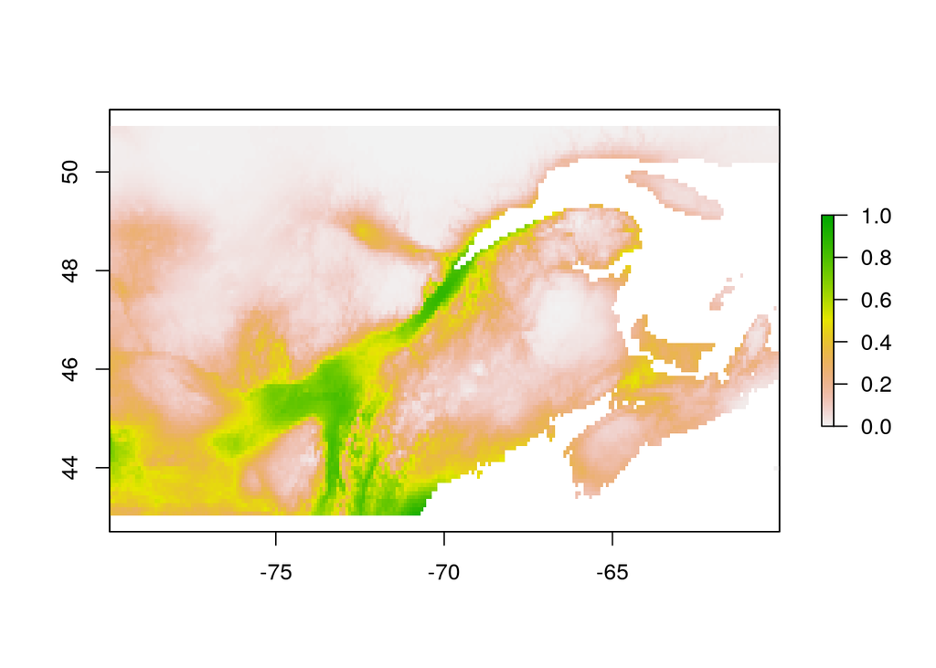

```r
# Calculate estimated values
spGAMPred <- predict(spGAM,
                         newdata = explanaAll,
                         type = "response")

# Build raster
spGAM <- raster(climatePresent)

# Find where to place the values in the raster
values(spGAM) <- as.vector(spGAMPred)

# Map
plot(spGAM, zlim = c(0,1))
```

# Exercice

- Model the distribution for another bird species

# To keep in mind

- This is not only model fitting, have an ecological perspective
- The data has particularities, be aware of it
- Remember the assumptions that you make when building your model
- Remember that the reason why you are modelling a species may skew the way you build and interpret the model.